[figure not shown]

# Weekly Statistics

Siaya County - Household Sample

### Income

**Earnings per capita (USD, PPP) - past 14 days**

Households are assigned the high asset category if they reported higher asset holdings than the median household in a 2014-2015 baseline survey. Asset holdings data is only available for the 2014-2015 survey sample, which is a subsample of the current panel of households.

##### All

[interactive chart not shown]

This plot shows income from three earning sources, across all working-age household members, and the average earning per capita, including children, in the past 14 days. If the household does not perceive income from one or more of the sources, those data points are assigned zeros to assure representativeness for the whole population.

##### High assets

[interactive chart not shown]

This plot shows income from three earning sources, across all working-age household members, and the average earning per capita, including children, in the past 14 days. If the household does not perceive income from one or more of the sources, those data points are assigned zeros to assure representativeness for the whole population.

##### Low assets

[interactive chart not shown]

This plot shows income from three earning sources, across all working-age household members, and the average earning per capita, including children, in the past 14 days. If the household does not perceive income from one or more of the sources, those data points are assigned zeros to assure representativeness for the whole population.

##### Household with children

[interactive chart not shown]

This plot shows income from three earning sources, across all working-age household members, and the average earning per capita, including children, in the past 14 days. If the household does not perceive income from one or more of the sources, those data points are assigned zeros to assure representativeness for the whole population.

##### No children

[interactive chart not shown]

This plot shows income from three earning sources, across all working-age household members, and the average earning per capita, including children, in the past 14 days. If the household does not perceive income from one or more of the sources, those data points are assigned zeros to assure representativeness for the whole population.

**Hourly Wages**

##### All

Hourly wages calculated by dividing total wages by total hours worked at the individual level, conditional on employment. Averages weighted by total hours worked at the individual level multiplied by household level weights.

[interactive chart not shown]

##### High assets

Hourly wages calculated by dividing total wages by total hours worked at the individual level, conditional on employment. Averages weighted by total hours worked at the individual level multiplied by household level weights.

[interactive chart not shown]

##### Low assets

Hourly wages calculated by dividing total wages by total hours worked at the individual level, conditional on employment. Averages weighted by total hours worked at the individual level multiplied by household level weights.

[interactive chart not shown]

**Dissaving per capita (USD, PPP) - past 14 days**  
The dissaving variable is constructed by adding the value of assets sold and loans taken, and substracting the value of any assets or durables bought.

##### All

[interactive chart not shown]

##### High assets

[interactive chart not shown]

##### Low assets

[interactive chart not shown]

##### Household with children

[interactive chart not shown]

##### No children

[interactive chart not shown]

**Percentage of households receiving support - past 14 days**

##### All

We ask whether in the past 14 days anyone in the household received a gift/assistance of money or goods, and its value, from (i) the government, (ii) from a non-governmental organization or community group, or (iii) from an individual politician or government official.

[interactive chart not shown]

##### High assets

We ask whether in the past 14 days anyone in the household received a gift/assistance of money or goods, and its value, from (i) the government, (ii) from a non-governmental organization or community group, or (iii) from an individual politician or government official.

[interactive chart not shown]

##### Low assets

We ask whether in the past 14 days anyone in the household received a gift/assistance of money or goods, and its value, from (i) the government, (ii) from a non-governmental organization or community group, or (iii) from an individual politician or government official.

[interactive chart not shown]

##### Household with children

We ask whether in the past 14 days anyone in the household received a gift/assistance of money or goods, and its value, from (i) the government, (ii) from a non-governmental organization or community group, or (iii) from an individual politician or government official.

[interactive chart not shown]

##### No children

We ask whether in the past 14 days anyone in the household received a gift/assistance of money or goods, and its value, from (i) the government, (ii) from a non-governmental organization or community group, or (iii) from an individual politician or government official.

[interactive chart not shown]

### Consumption

**Weekly consumption per capita (USD, PPP)**

Households are assigned the high asset category if they reported higher asset holdings than the median household in a 2014-2015 baseline survey. Asset holdings data is only available for the 2014-2015 survey sample, which is a subsample of the current panel of households.

##### All

[interactive chart not shown]

Own-food consumption accounts for own agricultural and pastoral production at market value. Pre-covid average uses 2016-2017 data.

##### High assets

[interactive chart not shown]

Own-food consumption accounts for own agricultural and pastoral production at market value. Pre-covid average uses 2016-2017 data.

##### Low assets

[interactive chart not shown]

Own-food consumption accounts for own agricultural and pastoral production at market value. Pre-covid average uses 2016-2017 data.

##### Household with children

[interactive chart not shown]

Own-food consumption accounts for own agricultural and pastoral production at market value. Pre-covid average uses 2016-2017 data.

##### No children

[interactive chart not shown]

Own-food consumption accounts for own agricultural and pastoral production at market value. Pre-covid average uses 2016-2017 data.

### Food Security

**Number of days skipping meals in the past 7 days**

Households are assigned the high asset category if they reported higher asset holdings than the median household in a 2014-2015 baseline survey. Asset holdings data is only available for the 2014-2015 survey sample, which is a subsample of the current panel of households.

##### All

[interactive chart not shown]

Pre-COVID average uses data from 2016-2017.

##### High assets

[interactive chart not shown]

Pre-COVID average uses data from 2016-2017.

##### Low assets

[interactive chart not shown]

Pre-COVID average uses data from 2016-2017.

##### Household with children

[interactive chart not shown]

Pre-COVID average uses data from 2016-2017.

##### No children

[interactive chart not shown]

Pre-COVID average uses data from 2016-2017.

**Percentage of sample unable to buy usual amount of food due to:**

##### All

We ask whether in the past 7 days, any household member was unable to buy the amount of food they usually buy because of: (i) price of food being too high, (ii) household income having dropped, and (iii) shortages in markets.

[interactive chart not shown]

##### High assets

We ask whether in the past 7 days, any household member was unable to buy the amount of food they usually buy because of: (i) price of food being too high, (ii) household income having dropped, and (iii) shortages in markets.

[interactive chart not shown]

##### Low assets

We ask whether in the past 7 days, any household member was unable to buy the amount of food they usually buy because of: (i) price of food being too high, (ii) household income having dropped, and (iii) shortages in markets.

[interactive chart not shown]

**Other food hardship experiences, percentage of sample**

##### All

We ask whether in the past 7 days, any household member experienced: (i) having to reduce the number of meals and/or the portion of each meal they would usually eat, (ii) difficulties in going to food markets due to mobility restrictions imposed by government, and (iii) difficulties in buying food due to most food markets being closed.

[interactive chart not shown]

##### High assets

We ask whether in the past 7 days, any household member experienced: (i) having to reduce the number of meals and/or the portion of each meal they would usually eat, (ii) difficulties in going to food markets due to mobility restrictions imposed by government, and (iii) difficulties in buying food due to most food markets being closed.

[interactive chart not shown]

##### Low assets

We ask whether in the past 7 days, any household member experienced: (i) having to reduce the number of meals and/or the portion of each meal they would usually eat, (ii) difficulties in going to food markets due to mobility restrictions imposed by government, and (iii) difficulties in buying food due to most food markets being closed.

[interactive chart not shown]

### Loans

**Households taking a new loan for consumption**  
We ask “In the past 14 days, did anyone in this household take out a new loan for use on household consumption?”

[interactive chart not shown]

**Type of loan taken**  
“If yes, what kind of loan?”

[interactive chart not shown]

These plots show the distribution of the type of loans taken over time, conditional on the household taking a loan.

### Household enterprises

**Enterprises revenue and profits in the past 14 days**

Households are assigned the high asset category if they reported higher asset holdings than the median household in a 2014-2015 baseline survey. Asset holdings data is only available for the 2014-2015 survey sample, which is a subsample of the current panel of households.

##### All

[interactive chart not shown]

##### High assets

[interactive chart not shown]

##### Low assets

[interactive chart not shown]

### COVID-19

**Reported COVID-19 Behavior Adoption**

Households are assigned the high asset category if they reported higher asset holdings than the median household in a 2014-2015 baseline survey. Asset holdings data is only available for the 2014-2015 survey sample, which is a subsample of the current panel of households.

##### All

We ask respondents whether they have changed their behavior in any way since learning about COVID-19, and if so, how it has changed.

[interactive chart not shown]

##### High assets

We ask respondents whether they have changed their behavior in any way since learning about COVID-19, and if so, how it has changed.

[interactive chart not shown]

##### Low assets

We ask respondents whether they have changed their behavior in any way since learning about COVID-19, and if so, how it has changed.

[interactive chart not shown]

##### Female

We ask respondents whether they have changed their behavior in any way since learning about COVID-19, and if so, how it has changed.

[interactive chart not shown]

##### Male

We ask respondents whether they have changed their behavior in any way since learning about COVID-19, and if so, how it has changed.

[interactive chart not shown]

**Reported COVID-19 Symptoms, past 14 days**

##### All

We ask respondents whether they have experienced any illnesses or symptoms of a given list in the past 14 days.

[interactive chart not shown]

##### High assets

We ask respondents whether they have experienced any illnesses or symptoms of a given list in the past 14 days.

[interactive chart not shown]

##### Low assets

We ask respondents whether they have experienced any illnesses or symptoms of a given list in the past 14 days.

[interactive chart not shown]

##### Female

We ask respondents whether they have experienced any illnesses or symptoms of a given list in the past 14 days.

[interactive chart not shown]

##### Male

We ask respondents whether they have experienced any illnesses or symptoms of a given list in the past 14 days.

[interactive chart not shown]

**Number of in-person interactions (other than HH members)**

##### All

We ask: “Taken together, how many people outside this household have you interacted with in-person?”

[interactive chart not shown]

##### High assets

We ask: “Taken together, how many people outside this household have you interacted with in-person?”

[interactive chart not shown]

##### Low assets

We ask: “Taken together, how many people outside this household have you interacted with in-person?”

[interactive chart not shown]

##### Female

We ask: “Taken together, how many people outside this household have you interacted with in-person?”

[interactive chart not shown]

##### Male

We ask: “Taken together, how many people outside this household have you interacted with in-person?”

[interactive chart not shown]

**Face mask usage by activity / location**

Conditional on visiting location / participating in the activity. We present two variables, the first one is self-reported mask usage and the second one is the observed proportion of other people using a face mask.

##### All

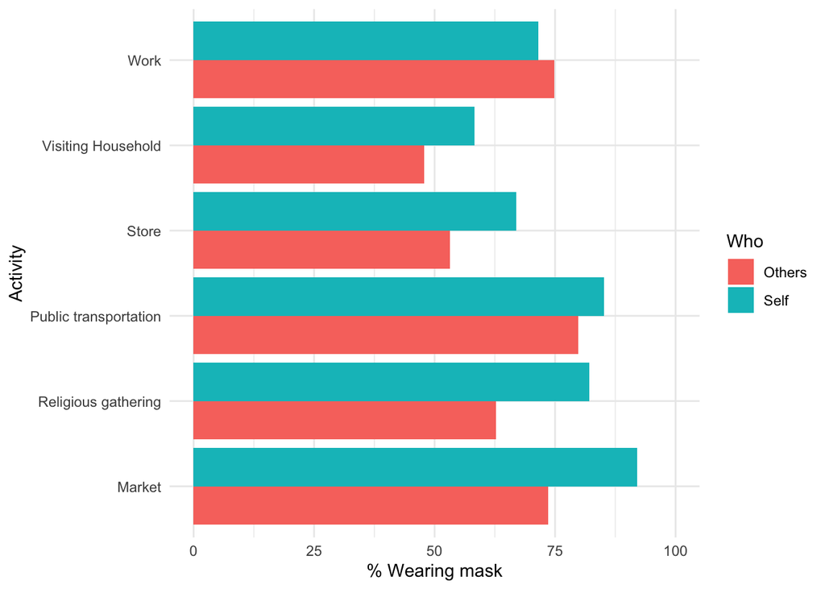

##### High assets

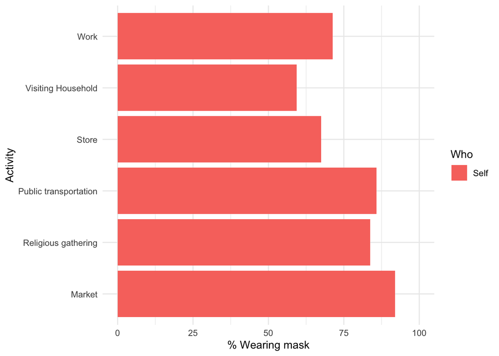

##### Low assets

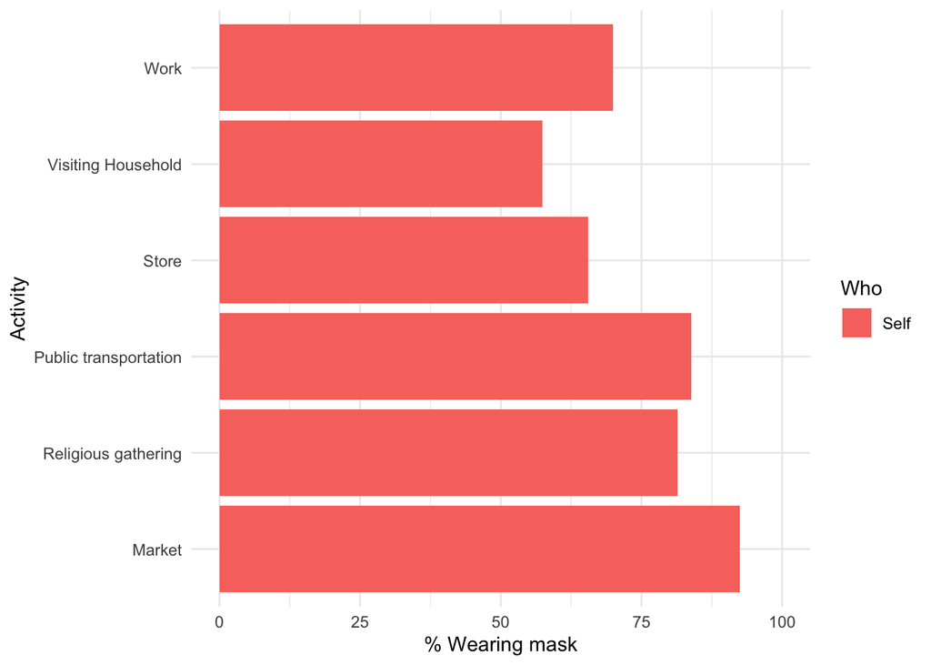

##### Male

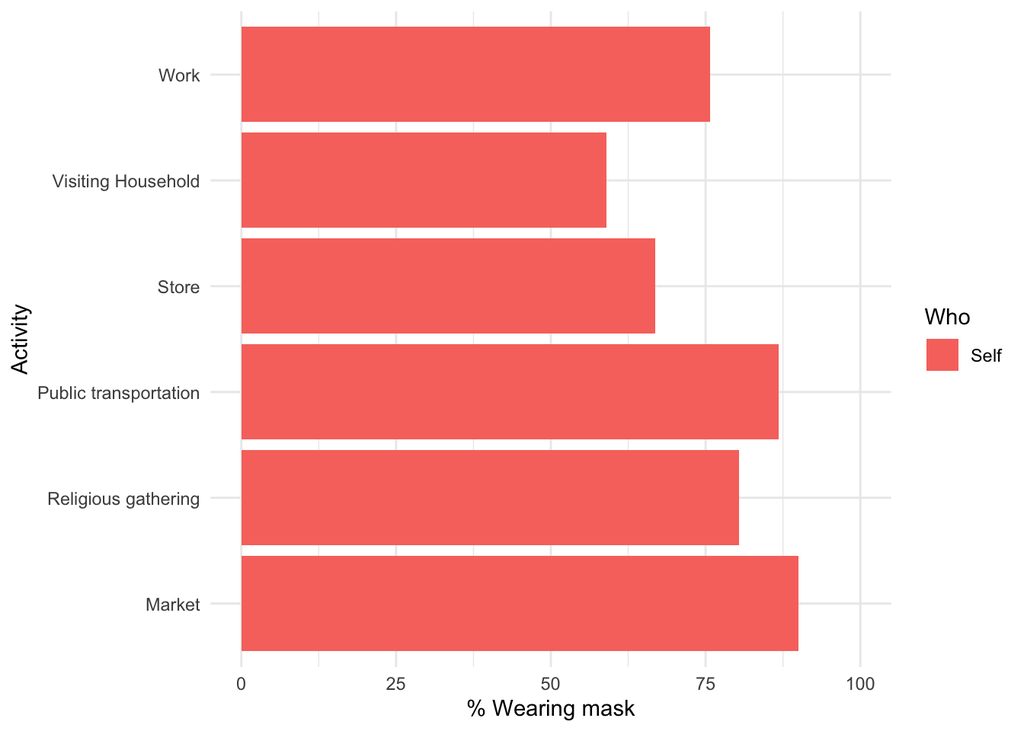

##### Female

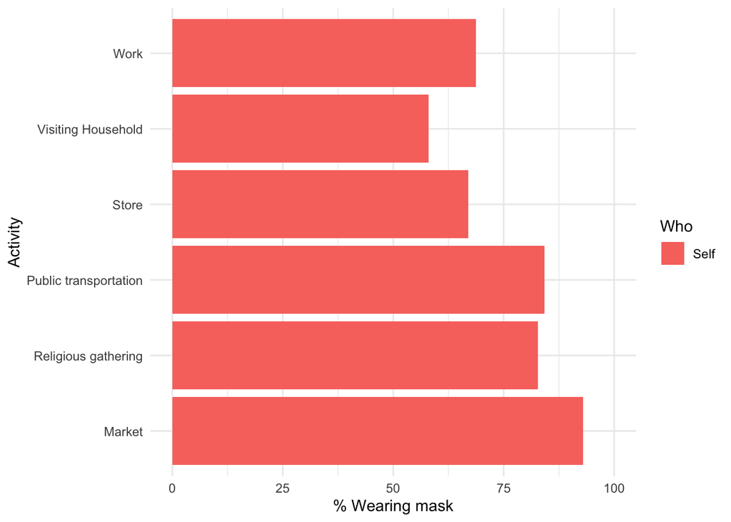

**Visited or had visitors from another household, past 14 days**

##### All

[interactive chart not shown]

##### High assets

[interactive chart not shown]

##### Low assets

[interactive chart not shown]

##### Household with children

[interactive chart not shown]

##### No children

[interactive chart not shown]

### Labor Supply

**Weekly labor supply (hours per household adult)**

Households are assigned the high asset category if they reported higher asset holdings than the median household in a 2014-2015 baseline survey. Asset holdings data is only available for the 2014-2015 survey sample, which is a subsample of the current panel of households.

##### All

[interactive chart not shown]

This plot aggregates hours worked on each of the three sources, across all working-age household members, stacking them to add to the average weekly labor supply per household adult. If the household does not work any hours on one or more of the labor categories, those data points are assigned zeros to assure representativeness of the whole population.

##### High assets

[interactive chart not shown]

This plot aggregates hours worked on each of the three sources, across all working-age household members, stacking them to add to the average weekly labor supply per household adult. If the household does not work any hours on one or more of the labor categories, those data points are assigned zeros to assure representativeness of the whole population.

##### Low assets

[interactive chart not shown]

This plot aggregates hours worked on each of the three sources, across all working-age household members, stacking them to add to the average weekly labor supply per household adult. If the household does not work any hours on one or more of the labor categories, those data points are assigned zeros to assure representativeness of the whole population.

##### Household with children

[interactive chart not shown]

This plot aggregates hours worked on each of the three sources, across all working-age household members, stacking them to add to the average weekly labor supply per household adult. If the household does not work any hours on one or more of the labor categories, those data points are assigned zeros to assure representativeness of the whole population.

##### No children

[interactive chart not shown]

This plot aggregates hours worked on each of the three sources, across all working-age household members, stacking them to add to the average weekly labor supply per household adult. If the household does not work any hours on one or more of the labor categories, those data points are assigned zeros to assure representativeness of the whole population.

### Children Education

**Children educational activities**

Households are assigned the high asset category if they reported higher asset holdings than the median household in a 2014-2015 baseline survey. Asset holdings data is only available for the 2014-2015 survey sample, which is a subsample of the current panel of households.

##### All

We ask what has each child been doing over the last 15 minutes, whether the child has done any learning-related activities in the past 24 hours, and if so, what kind of activity. From this question we also learn whether the child attended school.

[interactive chart not shown]

##### High assets

We ask what has each child been doing over the last 15 minutes, whether the child has done any learning-related activities in the past 24 hours, and if so, what kind of activity. From this question we also learn whether the child attended school.

[interactive chart not shown]

##### Low assets

We ask what has each child been doing over the last 15 minutes, whether the child has done any learning-related activities in the past 24 hours, and if so, what kind of activity. From this question we also learn whether the child attended school.

[interactive chart not shown]

### Household Violence

**Gender violence**

Households are assigned the high asset category if they reported higher asset holdings than the median household in a 2014-2015 baseline survey. Asset holdings data is only available for the 2014-2015 survey sample, which is a subsample of the current panel of households.

##### All

We ask married/cohabitant female respondents whether their husband/partner has (i) threaten to harm them or someone close to them, (ii) hit, slapped, kicked, or physically hurt them, and (iii) forced them to perform sexual acts.*

[interactive chart not shown]

*This plot shows data only for the share of female respondents that were surveyed by a female field officer, and are currently married or living with a partner. This sub-sample accounts for ~55% of all married/cohabitant females in the study sample, and ~36% of all females.

##### High assets

We ask married/cohabitant female respondents whether their husband/partner has (i) threaten to harm them or someone close to them, (ii) hit, slapped, kicked, or physically hurt them, and (iii) forced them to perform sexual acts.*

[interactive chart not shown]

*This plot shows data only for the share of female respondents that were surveyed by a female field officer, and are currently married or living with a partner. This sub-sample accounts for ~55% of all married/cohabitant females in the study sample, and ~36% of all females.

##### Low assets

We ask married/cohabitant female respondents whether their husband/partner has (i) threaten to harm them or someone close to them, (ii) hit, slapped, kicked, or physically hurt them, and (iii) forced them to perform sexual acts.*

[interactive chart not shown]

*This plot shows data only for the share of female respondents that were surveyed by a female field officer, and are currently married or living with a partner. This sub-sample accounts for ~55% of all married/cohabitant females in the study sample, and ~36% of all females.

**Violence in the household**

##### All

We ask: (i) Over the past 14 days, has there been a higher than usual amount of fights with members of your household?, and (ii) In the past 14 days, did you or your partner ever beat any of the children living in this household?

[interactive chart not shown]

##### High assets

We ask: (i) Over the past 14 days, has there been a higher than usual amount of fights with members of your household?, and (ii) In the past 14 days, did you or your partner ever beat any of the children living in this household?

[interactive chart not shown]

##### Low assets

We ask: (i) Over the past 14 days, has there been a higher than usual amount of fights with members of your household?, and (ii) In the past 14 days, did you or your partner ever beat any of the children living in this household?

[interactive chart not shown]

### Trust

**Trust in government**

Households are assigned the high asset category if they reported higher asset holdings than the median household in a 2014-2015 baseline survey. Asset holdings data is only available for the 2014-2015 survey sample, which is a subsample of the current panel of households.

##### All

How much do you trust your country’s government to take care of its citizens?

[interactive chart not shown]

##### High assets

How much do you trust your country’s government to take care of its citizens?

[interactive chart not shown]

##### Low assets

How much do you trust your country’s government to take care of its citizens?

[interactive chart not shown]

##### Female

How much do you trust your country’s government to take care of its citizens?

[interactive chart not shown]

##### Male

How much do you trust your country’s government to take care of its citizens?

[interactive chart not shown]

**Trust in other people**

##### All

Generally speaking, would you say that most people can be trusted or that you need to be very careful in dealing with people?

[interactive chart not shown]

##### High assets

Generally speaking, would you say that most people can be trusted or that you need to be very careful in dealing with people?

[interactive chart not shown]

##### Low assets

Generally speaking, would you say that most people can be trusted or that you need to be very careful in dealing with people?

[interactive chart not shown]

##### Female

Generally speaking, would you say that most people can be trusted or that you need to be very careful in dealing with people?

[interactive chart not shown]

##### Male

Generally speaking, would you say that most people can be trusted or that you need to be very careful in dealing with people?

[interactive chart not shown]

### Mental health

**Depression, CES-D-10**

Households are assigned the high asset category if they reported higher asset holdings than the median household in a 2014-2015 baseline survey. Asset holdings data is only available for the 2014-2015 survey sample, which is a subsample of the current panel of households.

##### All

**The Centre for Epidemiological Studies Depression Scale** (CES-D-10) is a 10-item Likert scale questionnaire assessing depressive symptoms in the past week. It includes three items on depressed affect, five items on somatic symptoms, and two on positive affect. Options for each item range from “rarely or none of the time” (score of 0) to “all of the time” (score of 3). Scoring is reversed for positive affect statements. Total scores can range from 0 to 30. **Higher scores suggest greater severity of symptoms.**

[interactive chart not shown]

Pre-COVID average computed with data from 2016-2017

##### High assets

**The Centre for Epidemiological Studies Depression Scale** (CES-D-10) is a 10-item Likert scale questionnaire assessing depressive symptoms in the past week. It includes three items on depressed affect, five items on somatic symptoms, and two on positive affect. Options for each item range from “rarely or none of the time” (score of 0) to “all of the time” (score of 3). Scoring is reversed for positive affect statements. Total scores can range from 0 to 30. **Higher scores suggest greater severity of symptoms.**

[interactive chart not shown]

Pre-COVID average computed with data from 2016-2017

##### Low assets

**The Centre for Epidemiological Studies Depression Scale** (CES-D-10) is a 10-item Likert scale questionnaire assessing depressive symptoms in the past week. It includes three items on depressed affect, five items on somatic symptoms, and two on positive affect. Options for each item range from “rarely or none of the time” (score of 0) to “all of the time” (score of 3). Scoring is reversed for positive affect statements. Total scores can range from 0 to 30. **Higher scores suggest greater severity of symptoms.**

[interactive chart not shown]

Pre-COVID average computed with data from 2016-2017

##### Female

**The Centre for Epidemiological Studies Depression Scale** (CES-D-10) is a 10-item Likert scale questionnaire assessing depressive symptoms in the past week. It includes three items on depressed affect, five items on somatic symptoms, and two on positive affect. Options for each item range from “rarely or none of the time” (score of 0) to “all of the time” (score of 3). Scoring is reversed for positive affect statements. Total scores can range from 0 to 30. **Higher scores suggest greater severity of symptoms.**

[interactive chart not shown]

Pre-COVID average computed with data from 2016-2017

##### Male

**The Centre for Epidemiological Studies Depression Scale** (CES-D-10) is a 10-item Likert scale questionnaire assessing depressive symptoms in the past week. It includes three items on depressed affect, five items on somatic symptoms, and two on positive affect. Options for each item range from “rarely or none of the time” (score of 0) to “all of the time” (score of 3). Scoring is reversed for positive affect statements. Total scores can range from 0 to 30. **Higher scores suggest greater severity of symptoms.**

[interactive chart not shown]

Pre-COVID average computed with data from 2016-2017

##### Household with children

**The Centre for Epidemiological Studies Depression Scale** (CES-D-10) is a 10-item Likert scale questionnaire assessing depressive symptoms in the past week. It includes three items on depressed affect, five items on somatic symptoms, and two on positive affect. Options for each item range from “rarely or none of the time” (score of 0) to “all of the time” (score of 3). Scoring is reversed for positive affect statements. Total scores can range from 0 to 30. **Higher scores suggest greater severity of symptoms.**

[interactive chart not shown]

Pre-COVID average computed with data from 2016-2017

##### No children

**The Centre for Epidemiological Studies Depression Scale** (CES-D-10) is a 10-item Likert scale questionnaire assessing depressive symptoms in the past week. It includes three items on depressed affect, five items on somatic symptoms, and two on positive affect. Options for each item range from “rarely or none of the time” (score of 0) to “all of the time” (score of 3). Scoring is reversed for positive affect statements. Total scores can range from 0 to 30. **Higher scores suggest greater severity of symptoms.**

[interactive chart not shown]

Pre-COVID average computed with data from 2016-2017

We also ask questions 1-5 on core mental health from the John Hopkins Bloomberg School of Public Health (JHSPH) [resource](https://www.elizabethstuart.org/files/MH_survey-items-request_03_20.pdf).

**Nervious, anxious or on edge**

In the past 7 days, how often have you felt nervous, anxious, or on edge?

[interactive chart not shown]

**Depressed**

In the past 7 days, how often have you felt depressed?

[interactive chart not shown]

**Lonely**

In the past 7 days, how often have you felt lonely?

[interactive chart not shown]

**Hopeful about the future**

In the past 7 days, how often have you felt hopeful about the future?

[interactive chart not shown]

**Had physical reactions due to COVID-19**

In the past 7 days, how often have you had physical reactions, such as sweating, trouble breathing, nausea, or a pounding heart, when thinking about your experience (e.g., social distancing, loss of income/work, concerns about infection) with the coronavirus/COVID-19 pandemic?

[interactive chart not shown]

### Food prices

**Animal Products**

[interactive chart not shown]

**Fruits / Vegetables**

[interactive chart not shown]

**Grains / Other**

[interactive chart not shown]

### Other prices

**Services**

[interactive chart not shown]

**Livestock**

[interactive chart not shown]

**Non-food**

[interactive chart not shown]

Households are assigned the high asset category if they reported higher asset holdings than the median household in a 2014-2015 baseline survey. Asset holdings data is only available for the 2014-2015 survey sample, which is a subsample of the current panel of households.

Eligible households are those that qualified for [GiveDirectly transfers](http://emiguel.econ.berkeley.edu/assets/miguel_research/88/GE-Paper_2019-12-18.pdf) by living in homes with thatched roofs in 2014.

These data comes from phone survey interviews conducted by [REMIT Kenya](http://remitkenya.co.ke/) in Siaya County, Kenya. We are collecting data for a sample of ~11,000 households in the county, which is representative of the whole population. At the same time, our weekly sampling method assures weekly representativeness of the overall sample.

| Week | Dates | Number of surveys | Survey round |
| --- | --- | --- | --- |
| Week 1 | 05 April 2020 - 11 April 2020 | 745 | 1 |
| Week 2 | 12 April 2020 - 18 April 2020 | 744 | 1 |
| Week 3 | 19 April 2020 - 25 April 2020 | 1,478 | 1 |
| Week 4 | 26 April 2020 - 02 May 2020 | 1,146 | 1 |
| Week 5 | 03 May 2020 - 09 May 2020 | 1,499 | 1 |
| Week 6 | 10 May 2020 - 16 May 2020 | 986 | 1 |
| Week 7 | 17 May 2020 - 23 May 2020 | 1,217 | 1 |
| Week 8 | 24 May 2020 - 30 May 2020 | 771 | 1 |
| Week 12 | 21 June 2020 - 27 June 2020 | 1747 | 2 |
| Week 14 | 5 July 2020 - 11 July 2020 | 1087 | 2 |
| Week 15 | 12 July 2020 - 18 July 2020 | 611 | 2 |
| Week 16 | 19 July 2020 - 25 July 2020 | 889 | 2 |
| Week 17 | 26 July 2020 - 1 August 2020 | 820 | 2 |
| Week 18 | 2 August 2020 - 8 August 2020 | 870 | 2 |
| Week 19 | 9 August 2020 - 15 August 2020 | 835 | 2 |
| Week 20 | 16 August 2020 - 22 August 2020 | 886 | 2 |
| Week 21 | 23 August 2020 - 29 August 2020 | 1,042 | 2 |